# Access to Itaú Bikes in Recife

Author

Vinicius Hiago e Silva Gerônimo

Published

June 23, 2025

#### The following map identifies all areas in Recife that are within a 30-minute walk of an Itaú bike station, highlighting the system’s effective service area versus the regions left unserved.

## Itaú bike stations

To identify the station locations, I used a file available at **dados.recife.gov.br**, which shows the location of all stations that existed as of January 2024.

```r
# Read file
estacoes = read_delim("estacoes.csv",
    delim = ";", escape_double = FALSE, trim_ws = TRUE)

# Geocoding stations
estacoes = st_as_sf(
  estacoes,
  coords = c("longitude", "latitude"),
  crs = 4326
  )
```

## Grids

The hexagonal grid was created using the `h3jsr` package in R, which provides access to **Uber’s H3** geospatial indexing system. H3 is a hierarchical grid system composed of hexagons at multiple resolution levels. For this analysis, **resolution 9** was chosen, which corresponds to hexagons with an average area of approximately 0.11 square kilometers.

```r
# Get municipality border
recife_sf = read_municipality(code_muni = 2611606)
recife_sf = st_transform(recife_sf, crs = 4326)

# Filter only the stations in Recife
stations_em_recife_sf = st_filter(estacoes, recife_sf)


# Create the grids
grid_recife = polygon_to_cells(recife_sf,
                                res = 9,
                                simple = FALSE)


grid_recife = cell_to_polygon(grid_recife$h3_addresses,
                               simple = FALSE)
```

## Isochrones

This analysis uses isochrones—polygons that show the reachable area from a location within a specific timeframe. Using the `osrm` package, which interfaces with **OpenStreetMap**’s routing engine, I generated a **30-minute walking** isochrone for each bike station to map the system’s overall service area.

```r
# Create a function to get the isochrone.
get_isochrone = function(df) {
  iso = osrmIsochrone(
    loc = df[1, ],
    breaks = c(0, 30),
    osrm.profile = "foot"
  )
  return(iso)
}


# Create a list where each item corresponds to a station.
lista_de_estacoes = split(stations_em_recife_sf, f = stations_em_recife_sf$codigo)


# Apply the function to each station
lista_de_isocronas = lapply(lista_de_estacoes, get_isochrone)

sf_use_s2(FALSE)

lista_de_isocronas_limpas = lapply(lista_de_isocronas, function(iso_individual) {
  st_buffer(iso_individual, dist = 0)
})


# Group the results
mapa_isocronas_final = bind_rows(lista_de_isocronas_limpas) %>% st_union()
```

To determine which parts of the city have access, all individual station service areas (isochrones) were first merged into a single comprehensive coverage area. Then, each hexagonal cell of the city grid was spatially checked against this coverage area, and categorized as either having access (‘Yes’) or not (‘No’).

```r
# Checks whether a geometry is valid
mapa_isocronas_final = st_union(mapa_isocronas_final) %>% st_make_valid()

# Intersection of the grid and the isochrones
intersecao = st_intersects(grid_recife, mapa_isocronas_final, sparse = FALSE)

# Labelled each grid
grid_recife$tem_acesso = ifelse(intersecao[, 1], "Sim", "Não")
```

## Map

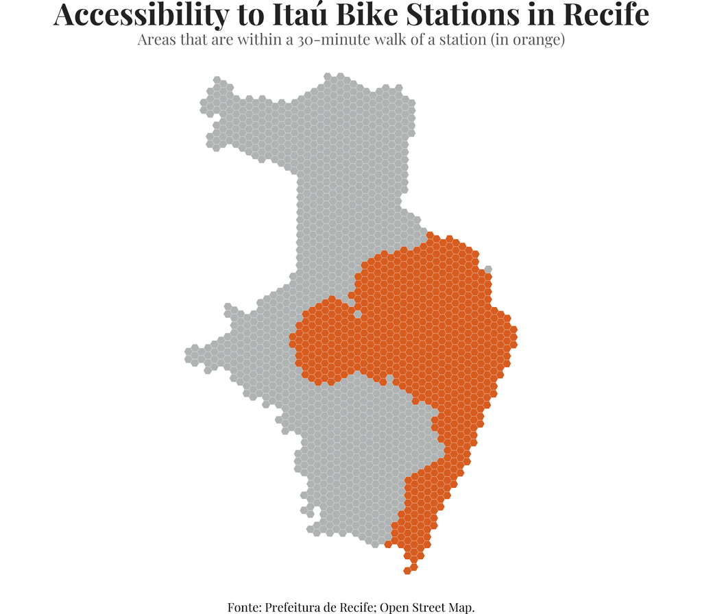

```r
ggplot() +
  geom_sf(data = grid_recife, aes(fill = tem_acesso), color = "white", linewidth = 0.01) +
    scale_fill_manual(values = c("Sim" = "#D75C20", "Não" = "#AFB3B3")) +
  labs(
    title = "Accessibility to Itaú Bike Stations in Recife",
    subtitle = "Areas that are within a 30-minute walk of a station (in orange)",
    caption = "Fonte: Prefeitura de Recife; Open Street Map."
  ) +
  theme_void() +
  theme(
    plot.title = element_text(family = "pf", size = 100, face = "bold", color = "#222222", hjust = 0.5),
    plot.subtitle = element_text(family = "pf", size = 50, color = "#555555", hjust = 0.5),
    legend.text = element_text(family = "pf", size = 45),
    plot.caption = element_text(family = "pf", size = 40, hjust = 0.5),
    legend.position = 'none',
    legend.key.width = unit(1.8, "cm"),
    legend.key.size= unit(0.7, "cm")
  )
```